← All notes Source: `20_DDIM_explained.ipynb`

Get the notebook ↓ Download .ipynb [▶ Open in Colab](https://colab.research.google.com/github/shammun/shammunul-fastai-notes/blob/main/notebooks/20_DDIM_explained_colab.ipynb)

# Denoising Diffusion Implicit Models (DDIM)

## Complete Beginner's Guide

This notebook introduces **DDIM** - a faster way to generate images from diffusion models. While DDPM requires many steps (often 1000) to generate good images, DDIM can produce similar quality with far fewer steps (50-100).

### What You'll Learn

1. **The Problem with DDPM**: Why 1000 steps is slow
2. **DDIM Solution**: A deterministic (or partially stochastic) sampling method
3. **The eta (η) Parameter**: Control the randomness
4. **HuggingFace Schedulers**: Using pre-built DDPM and DDIM schedulers
5. **Implementing DDIM from Scratch**: Understanding the math
6. **Triangular Noise**: A training improvement

### Prerequisites

- Basic Python knowledge
- Understanding of DDPM from previous notebooks (helpful but not required)

### DDPM vs DDIM Quick Comparison

```
DDPM (Denoising Diffusion Probabilistic Models):
- Stochastic (random) sampling
- Requires ~1000 steps for good quality
- Each run with same starting noise → different image

DDIM (Denoising Diffusion Implicit Models):
- Can be deterministic (eta=0) or stochastic (eta=1)
- Works well with 50-200 steps
- When deterministic: same starting noise → same image
```

## 🛠️ Interactive visualizations — one-time setup

The cells marked **🎮 Interactive** below embed standalone HTML/JS visualizations (stored in the `interactive_viz/` folder / published on GitHub Pages) at **full width**, auto-fitted to their content height (no empty space below). Run the next cell once, then run any 🎮 cell. Every visualization follows the same grammar: **numbered chips replay their part of the story**, a *live card* narrates the current instant with real schedule numbers, a *"How to read it"* line decodes the visual encoding, and the matching code lines light up in sync.

```python
# ============================================================================
# INTERACTIVE VISUALIZATIONS -- setup (run this cell ONCE).
# Each "🎮 Interactive" cell below loads a standalone HTML file from the
# published copy on GitHub Pages, in an isolated <iframe> (its CSS/JS can't leak
# into the notebook). It is shown FULL WIDTH and auto-fits its content height.
# No local files needed -- the visualizations are read from GitHub.
# ============================================================================
from IPython.display import HTML

def show_viz(path, height="600px"):
    """Embed an interactive visualization full width; it auto-fits its height.
    `path` may be a bare 'interactive_viz/<file>.html' (resolved to the GitHub
    Pages copy) or a full https URL."""
    base = "https://shammun.github.io/shammunul-fastai-notes/notebooks/"
    if not path.startswith("http"):
        path = base + path
    return HTML(
        f'<iframe src="{path}" loading="lazy" allowfullscreen '
        f'style="width:100%;height:{height};border:1px solid #dde5f2;border-radius:12px;'
        f'box-shadow:0 8px 24px rgba(123,92,214,.12);background:#fff;"></iframe>'
        '<script>addEventListener("message",function(e){'
        'if(e.data&&e.data.type==="ce-frame-height"&&e.data.height>50){'
        'var fs=document.querySelectorAll("iframe");for(var i=0;i<fs.length;i++){'
        'if(fs[i].contentWindow===e.source){fs[i].style.height=e.data.height+"px";break;}}}});</script>'
    )
```

## Theoretical Background: DDPM vs DDIM

Before diving into the code, let's understand the **mathematical foundations** of both DDPM and DDIM, and see exactly how DDIM achieves faster sampling.

### Quick Notation Reference

| Symbol | Name | Meaning |
| --- | --- | --- |
| x₀ | Original image | The clean image we want to generate |
| xₜ | Noisy image | Image at timestep t (more noise as t increases) |
| ε | Epsilon | Gaussian noise ~ N(0, I) |
| ε_θ | Model prediction | Neural network's prediction of the noise |
| αₜ | Alpha | Signal retention at step t: αₜ = 1 - βₜ |
| ᾱₜ | Alpha bar | Cumulative signal: ᾱₜ = α₁ × α₂ × ... × αₜ |
| βₜ | Beta | Noise variance added at step t |
| β̄ₜ | Beta bar | 1 - ᾱₜ (cumulative noise) |
| σₜ | Sigma | Noise level for sampling step |
| η | Eta | DDIM's stochasticity parameter (0 to 1) |

### The Forward Diffusion Process (Same for Both!)

Both DDPM and DDIM use the **same forward process** to add noise:

```
Forward Diffusion Formula:
┌─────────────────────────────────────────────────────────────┐
│                                                             │
│     xₜ = √(ᾱₜ) · x₀ + √(1 - ᾱₜ) · ε                        │
│           ────────     ────────────                         │
│           signal        noise                               │
│           part          part                                │
│                                                             │
│     where ε ~ N(0, I) is random Gaussian noise              │
│                                                             │
└─────────────────────────────────────────────────────────────┘
```

**Key insight**: Given a clean image x₀ and a timestep t, we can directly compute xₜ without going through intermediate steps. This is because the noise accumulation is a simple weighted sum.

```
Visualization of Forward Process:

t=0          t=250        t=500        t=750        t=999
x₀           x₂₅₀         x₅₀₀         x₇₅₀         x₉₉₉
┌────┐       ┌────┐       ┌────┐       ┌────┐       ┌────┐
│👕  │  ──►  │👕░ │  ──►  │░░░ │  ──►  │░░░ │  ──►  │░░░░│
│    │       │ ░  │       │░👕░│       │░░░░│       │░░░░│
└────┘       └────┘       └────┘       └────┘       └────┘
100% signal  75% signal   25% signal   5% signal   ~0% signal
0% noise     25% noise    75% noise    95% noise   100% noise

ᾱₜ ≈ 1.0     ᾱₜ ≈ 0.56    ᾱₜ ≈ 0.06    ᾱₜ ≈ 0.002   ᾱₜ ≈ 0.0
```

### The Reverse Process: Where DDPM and DDIM Differ!

The **reverse process** is where DDPM and DDIM diverge. Both aim to go from xₜ back to xₜ₋₁ (and eventually x₀), but they do it differently.

**The Core Problem:** Given xₜ (noisy image) and the model's noise prediction ε_θ(xₜ, t), how do we compute xₜ₋₁?

Both methods first estimate x₀ from xₜ:

```
Predicting x₀ from xₜ (Same for Both):
┌─────────────────────────────────────────────────────────────┐
│                                                             │
│            xₜ - √(1 - ᾱₜ) · ε_θ(xₜ, t)                      │
│     x̂₀ = ─────────────────────────────                      │
│                    √(ᾱₜ)                                    │
│                                                             │
│     This is just rearranging the forward formula!           │
│                                                             │
└─────────────────────────────────────────────────────────────┘

Derivation:
  xₜ = √(ᾱₜ) · x₀ + √(1-ᾱₜ) · ε
  xₜ - √(1-ᾱₜ) · ε = √(ᾱₜ) · x₀
  x₀ = (xₜ - √(1-ᾱₜ) · ε) / √(ᾱₜ)
```

Now comes the key difference: **How do we get from this predicted x₀ to xₜ₋₁?**

```python
# ============================================================================
# INTERACTIVE -- run this cell. It loads ./interactive_viz/1_ddim_theory_foundations.html
# at full width, sized to fit the visualization (setup cell near the top required).
# Theory foundations: the DDPM vs DDIM setup, laid side by side.
# ============================================================================
show_viz("interactive_viz/1_ddim_theory_foundations.html", height="700px")
```

[interactive chart not shown]

### 🎮 Interactive: the forward process — two faucets, one formula

Before going further, build intuition for the formula above. Two "faucets" pour the clean image x₀ and a fixed noise field ε into the mix xₜ — and the **faucet widths *are* the coefficients** √ᾱₜ and √(1−ᾱₜ), recomputed live from this notebook's real schedule (β: 0.0001→0.01) as you drag **t**. A purple marker rides the coefficient chart, and a dashed line marks the exact **crossover timestep where ᾱ = 0.5** (equal mix).

**Things to try:** press each numbered chip — they *replay* their segment (① Meet the pieces → ④ Wipe-out); watch the live SNR readout in dB flip sign at the crossover; drag t slowly through 0→40 and confirm you can't even see the noise yet.

```python
# ============================================================================
# INTERACTIVE -- run this cell. It loads ./interactive_viz/ddim_forward_diffusion.html
# at full width, sized to fit the visualization (setup cell near the top required).
# Faucet widths = mixing coefficients; live marker on the schedule chart; chips replay.
# ============================================================================
show_viz("interactive_viz/ddim_forward_diffusion.html", height="860px")
```

[interactive chart not shown]

## DDPM Reverse Process (Review)

DDPM uses a **stochastic** (random) reverse process derived from Bayesian inference.

### The DDPM Update Rule

```
┌─────────────────────────────────────────────────────────────────────────────┐
│                        DDPM UPDATE FORMULA                                  │
├─────────────────────────────────────────────────────────────────────────────┤
│                                                                             │
│                    1                    βₜ                                  │
│     xₜ₋₁ = ────────── (xₜ - ────────────── · ε_θ(xₜ,t)) + σₜ · z           │
│              √(αₜ)         √(1 - ᾱₜ)                                        │
│                                                                             │
│     where:                                                                  │
│       • z ~ N(0, I) is fresh random noise (independent of ε_θ)             │
│       • σₜ = √(βₜ) is the noise standard deviation                         │
│       • This noise z is MANDATORY in DDPM (except at t=0)                  │
│                                                                             │
└─────────────────────────────────────────────────────────────────────────────┘
```

### Alternative Form (Using x̂₀ Prediction)

DDPM can also be written in terms of predicted x₀:

```
Step 1: Predict clean image
        x̂₀ = (xₜ - √(1-ᾱₜ) · ε_θ) / √(ᾱₜ)

Step 2: Interpolate between xₜ and x̂₀, then add noise
                   √(ᾱₜ₋₁) · βₜ           √(αₜ) · (1-ᾱₜ₋₁)
        xₜ₋₁ = ─────────────────── · x̂₀ + ─────────────────── · xₜ + σₜ · z
                    1 - ᾱₜ                      1 - ᾱₜ
```

### Why DDPM Needs All 1000 Steps

**The Problem**: DDPM's derivation assumes you take **small steps** (t → t-1). The math relies on:

1. **Gaussian approximation**: Each step is a small perturbation
2. **Variance accumulation**: Noise adds up correctly only with consecutive steps
3. **Markov chain**: Each step only depends on the previous step

```
DDPM Markov Chain:
x_999 → x_998 → x_997 → ... → x_1 → x_0
  ↓       ↓       ↓            ↓     ↓
 z₉₉₉    z₉₉₈    z₉₉₇         z₁   (no z)

Each transition requires its own random noise z!
If you skip steps, the noise doesn't accumulate correctly.
```

**The Consequence**: If you try to skip steps in DDPM (e.g., t → t-10), the variance calculations break down, and you get poor quality images.

```python
# ============================================================================
# INTERACTIVE -- run this cell. It loads ./interactive_viz/2_ddpm_reverse_review.html
# at full width, sized to fit the visualization (setup cell near the top required).
# DDPM reverse process, reviewed one stochastic step at a time.
# ============================================================================
show_viz("interactive_viz/2_ddpm_reverse_review.html", height="700px")
```

[interactive chart not shown]

## DDIM Reverse Process: The Key Innovation

DDIM (Denoising Diffusion Implicit Models) introduces a **non-Markovian** generalization of the diffusion process. The key insight is that we can define a different reverse process that:

1. Still matches the same forward process (same training objective!)
2. Allows for **deterministic** sampling when η = 0
3. Can **skip timesteps** without breaking the math

### The DDIM Update Rule

```
┌─────────────────────────────────────────────────────────────────────────────┐
│                        DDIM UPDATE FORMULA                                  │
├─────────────────────────────────────────────────────────────────────────────┤
│                                                                             │
│     xₜ₋₁ = √(ᾱₜ₋₁) · x̂₀ + √(1 - ᾱₜ₋₁ - σₜ²) · ε_θ(xₜ,t) + σₜ · z         │
│             ──────────     ─────────────────────────────     ─────          │
│             "direction      "direction pointing to xₜ"     stochastic      │
│             to x₀"                                          noise          │
│                                                                             │
│     where:                                                                  │
│       • x̂₀ = (xₜ - √(1-ᾱₜ) · ε_θ) / √(ᾱₜ)  (predicted clean image)        │
│       • σₜ = η · √[(1-ᾱₜ₋₁)/(1-ᾱₜ)] · √[1 - ᾱₜ/ᾱₜ₋₁]  (noise level)       │
│       • z ~ N(0, I) is random noise (ONLY if σₜ > 0)                       │
│       • η ∈ [0, 1] controls stochasticity                                  │
│                                                                             │
└─────────────────────────────────────────────────────────────────────────────┘
```

### Understanding Each Term

Let's break down what each term in the DDIM formula does:

```
xₜ₋₁ = √(ᾱₜ₋₁) · x̂₀  +  √(1 - ᾱₜ₋₁ - σₜ²) · ε_θ  +  σₜ · z
       ───────────────   ───────────────────────    ────────
            Term 1              Term 2               Term 3


Term 1: √(ᾱₜ₋₁) · x̂₀
┌──────────────────────────────────────────────────────────────────┐
│ This term "aims toward" the predicted clean image x̂₀             │
│                                                                  │
│ - √(ᾱₜ₋₁) is how much signal should be at timestep t-1          │
│ - x̂₀ is our best guess of the clean image                       │
│ - Together: scale x̂₀ to the right signal level for t-1          │
└──────────────────────────────────────────────────────────────────┘

Term 2: √(1 - ᾱₜ₋₁ - σₜ²) · ε_θ
┌──────────────────────────────────────────────────────────────────┐
│ This term preserves the "noise direction" from the current step  │
│                                                                  │
│ - ε_θ is the model's predicted noise direction                   │
│ - The coefficient ensures total variance is correct              │
│ - Think of it as: "keep some predictable noise"                  │
└──────────────────────────────────────────────────────────────────┘

Term 3: σₜ · z
┌──────────────────────────────────────────────────────────────────┐
│ This term adds FRESH random noise                                │
│                                                                  │
│ - σₜ is controlled by η (eta parameter)                         │
│ - When η = 0: σₜ = 0, no fresh noise → DETERMINISTIC             │
│ - When η = 1: σₜ matches DDPM → STOCHASTIC                       │
│ - z ~ N(0,I) is independent random noise                         │
└──────────────────────────────────────────────────────────────────┘
```

### The σₜ Formula (Variance Control)

```
σₜ = η · √[(1 - ᾱₜ₋₁) / (1 - ᾱₜ)] · √[1 - ᾱₜ / ᾱₜ₋₁]
     ▲   ─────────────────────────────────────────────
     │              Base variance term
     │              (matches DDPM when η = 1)
     │
   Controls interpolation:
     η = 0: σₜ = 0 (no random noise)
     η = 1: σₜ matches DDPM variance
```

This formula is designed so that:

- The **total variance** of xₜ₋₁ is correct regardless of η
- When η = 1, it reduces to exactly DDPM
- When η = 0, all randomness is removed

### Why DDIM Can Skip Steps

The key mathematical insight: DDIM's formula only depends on:

- The **current** noisy image xₜ
- The **cumulative** noise levels ᾱₜ and ᾱₜ₋₁

It does **NOT** depend on the intermediate steps! This means we can go directly from t to any earlier timestep s < t:

```
DDPM (must go step by step):
x₉₉₉ → x₉₉₈ → x₉₉₇ → x₉₉₆ → ... → x₁ → x₀
  ↓       ↓       ↓       ↓            ↓
 z₉₉₉    z₉₉₈    z₉₉₇    z₉₉₆         z₁

Each step needs its own noise z. Skipping breaks the variance.


DDIM (can skip freely):
x₉₉₀ ─────────────────► x₉₈₀ ─────────────────► x₉₇₀ → ... → x₀
                │                       │
        (uses ᾱ₉₉₀ and ᾱ₉₈₀)   (uses ᾱ₉₈₀ and ᾱ₉₇₀)

Only needs ᾱ values for the timesteps we actually use!
The formula correctly handles any jump size.
```

```python
# ============================================================================
# INTERACTIVE -- run this cell. It loads ./interactive_viz/3_ddim_reverse_innovation.html
# at full width, sized to fit the visualization (setup cell near the top required).
# DDIM reverse process: the key non-Markovian innovation, unpacked.
# ============================================================================
show_viz("interactive_viz/3_ddim_reverse_innovation.html", height="700px")
```

[interactive chart not shown]

[figure not shown]

## Side-by-Side Comparison: DDPM vs DDIM

Now let's put everything together and see the exact differences:

### Update Formulas Compared

```
┌─────────────────────────────────────────────────────────────────────────────┐
│                    DDPM vs DDIM: THE KEY EQUATIONS                          │
├─────────────────────────────────────────────────────────────────────────────┤
│                                                                             │
│  BOTH start with predicting x₀:                                             │
│                                                                             │
│          xₜ - √(1-ᾱₜ) · ε_θ                                                 │
│    x̂₀ = ─────────────────────                                               │
│               √(ᾱₜ)                                                         │
│                                                                             │
├─────────────────────────────────────────────────────────────────────────────┤
│                                                                             │
│  DDPM Update:                                                               │
│  ───────────                                                                │
│            1          βₜ                                                    │
│    xₜ₋₁ = ─── (xₜ - ────── · ε_θ) + √(βₜ) · z                              │
│           √αₜ       √(1-ᾱₜ)                                                 │
│                                                                             │
│    - z is ALWAYS added (except at t=0)                                      │
│    - Cannot skip steps                                                      │
│    - Each step adds fresh random noise                                      │
│                                                                             │
├─────────────────────────────────────────────────────────────────────────────┤
│                                                                             │
│  DDIM Update:                                                               │
│  ───────────                                                                │
│    xₜ₋₁ = √(ᾱₜ₋₁) · x̂₀ + √(1-ᾱₜ₋₁-σₜ²) · ε_θ + σₜ · z                     │
│            ──────────    ────────────────────    ─────                      │
│            toward x₀     predicted noise         random                     │
│                          direction               noise                      │
│                                                                             │
│    - σₜ = η · √[(1-ᾱₜ₋₁)/(1-ᾱₜ)] · √[1-ᾱₜ/ᾱₜ₋₁]                           │
│    - When η=0: σₜ=0, no random noise → deterministic                        │
│    - When η=1: matches DDPM variance                                        │
│    - Can skip to any timestep (not just t-1)                                │
│                                                                             │
└─────────────────────────────────────────────────────────────────────────────┘
```

### Feature Comparison Table

| Feature | DDPM | DDIM |
| --- | --- | --- |
| **Process Type** | Markovian (each step depends only on previous) | Non-Markovian (can jump across timesteps) |
| **Randomness** | Always stochastic (z added every step) | Controllable via η parameter |
| **Minimum Steps** | ~1000 for good quality | 50-200 for good quality |
| **Same Noise → Same Image?** | No (different each run) | Yes when η=0 |
| **Training** | Same | Same (no retraining needed!) |
| **Update Formula** | Based on single-step Gaussian transition | Based on direct x₀ prediction |
| **Variance** | Fixed by noise schedule | Interpolated by η |

### Visual: The Two Sampling Strategies

```
DDPM Sampling (Stochastic Random Walk):
┌──────────────────────────────────────────────────────────────────────────┐
│                                                                          │
│  Start: x₉₉₉ (pure noise)                                               │
│         │                                                                │
│         ├──z₉₉₉──► x₉₉₈  (random step, adds noise z)                    │
│         │          │                                                     │
│         │          ├──z₉₉₈──► x₉₉₇                                      │
│         │          │          │                                          │
│         │          │          ├──z₉₉₇──► ...                            │
│         │          │          │                                          │
│         ▼          ▼          ▼                                          │
│                                                                          │
│  Path is a RANDOM WALK - same starting point, different paths each run  │
│                                                                          │
│  Like: Drunk person stumbling home, always ends up somewhere different  │
│                                                                          │
└──────────────────────────────────────────────────────────────────────────┘

DDIM Sampling (Deterministic when η=0):
┌──────────────────────────────────────────────────────────────────────────┐
│                                                                          │
│  Start: x₉₉₀ (pure noise)                                               │
│         │                                                                │
│         ├─────────────────► x₉₈₀  (direct jump, no random noise)        │
│         │                   │                                            │
│         │                   ├─────────────────► x₉₇₀                    │
│         │                   │                   │                        │
│         │                   │                   ├─────────────────► ...  │
│         ▼                   ▼                   ▼                        │
│                                                                          │
│  Path is DETERMINISTIC - same starting point, same path every time      │
│                                                                          │
│  Like: GPS navigation - always takes the exact same route               │
│                                                                          │
└──────────────────────────────────────────────────────────────────────────┘
```

### The η (Eta) Parameter Explained

The eta parameter is the key innovation of DDIM that controls the trade-off between:

- **Determinism** (reproducibility, same image every time)
- **Stochasticity** (variety, different images from same starting noise)

```
┌─────────────────────────────────────────────────────────────────────────────┐
│                         THE ETA (η) PARAMETER                               │
├─────────────────────────────────────────────────────────────────────────────┤
│                                                                             │
│  η controls the amount of random noise added at each step:                  │
│                                                                             │
│      σₜ = η · √[(1-ᾱₜ₋₁)/(1-ᾱₜ)] · √[1-ᾱₜ/ᾱₜ₋₁]                           │
│           ▲                                                                 │
│           │                                                                 │
│           └── When η = 0: σₜ = 0 (no random noise)                         │
│               When η = 1: σₜ = DDPM variance (full random noise)           │
│               When 0 < η < 1: Interpolation between the two               │
│                                                                             │
├─────────────────────────────────────────────────────────────────────────────┤
│                                                                             │
│  η = 0 (FULLY DETERMINISTIC)                                               │
│  ────────────────────────────                                               │
│                                                                             │
│  xₜ₋₁ = √(ᾱₜ₋₁) · x̂₀ + √(1-ᾱₜ₋₁) · ε_θ                                    │
│                          ▲                                                  │
│                          │                                                  │
│                    No random z term!                                        │
│                                                                             │
│  Properties:                                                                │
│  • Same starting noise → exact same final image                            │
│  • Reproducible results                                                     │
│  • Good for: interpolation, editing, consistent outputs                    │
│                                                                             │
├─────────────────────────────────────────────────────────────────────────────┤
│                                                                             │
│  η = 1 (EQUIVALENT TO DDPM)                                                │
│  ──────────────────────────                                                 │
│                                                                             │
│  xₜ₋₁ = √(ᾱₜ₋₁) · x̂₀ + √(1-ᾱₜ₋₁-σₜ²) · ε_θ + σₜ · z                       │
│                                                    ▲                        │
│                                                    │                        │
│                                              Full DDPM noise               │
│                                                                             │
│  Properties:                                                                │
│  • Same starting noise → different final image each run                    │
│  • More variety in outputs                                                  │
│  • Mathematically equivalent to DDPM sampling                              │
│                                                                             │
├─────────────────────────────────────────────────────────────────────────────┤
│                                                                             │
│  0 < η < 1 (INTERPOLATION)                                                 │
│  ──────────────────────────                                                 │
│                                                                             │
│  Properties:                                                                │
│  • Partial randomness                                                       │
│  • Same starting noise → slightly different images                         │
│  • Balance between reproducibility and variety                             │
│                                                                             │
└─────────────────────────────────────────────────────────────────────────────┘
```

### Practical Impact of η

```
η = 0:
┌────┐     ┌────┐     ┌────┐
│ 👕 │  →  │ 👕 │  →  │ 👕 │   (Always same output!)
└────┘     └────┘     └────┘
 Run 1      Run 2      Run 3

η = 1:
┌────┐     ┌────┐     ┌────┐
│ 👕 │  →  │ 👖 │  →  │ 👟 │   (Different outputs!)
└────┘     └────┘     └────┘
 Run 1      Run 2      Run 3

Starting from the SAME initial noise tensor!
```

### Summary: Why DDIM is Faster

1. **DDIM doesn't accumulate random noise** → No variance explosion from skipping
2. **Uses cumulative ᾱ values** → Works for any timestep gap
3. **Deterministic option** → Predictable behavior with fewer steps
4. **Same training** → No need to retrain the model!

```python
# ============================================================================
# INTERACTIVE -- run this cell. It loads ./interactive_viz/4_ddim_vs_ddpm_comparison.html
# at full width, sized to fit the visualization (setup cell near the top required).
# DDPM vs DDIM update rules, put side by side.
# ============================================================================
show_viz("interactive_viz/4_ddim_vs_ddpm_comparison.html", height="700px")
```

[interactive chart not shown]

### 🎮 Interactive: DDPM vs DDIM — same start, two ways home

One shared arena instead of two panels — because the punchline is that **both walkers leave the *same* pinned x_T** with the *same* model. The orange DDPM walker staggers home (watch the flashing fresh-`z` kicks and its climbing z-draw counter); the teal DDIM walker glides on one smooth curve. Chip ④ freezes mid-flight and dissects one step of each into arrows — the σ·z arrow simply doesn't exist for DDIM. Chip ⑤ sends a purple runner hopping bead-to-bead along the DDIM curve while a red ✗ shows a DDPM hop landing off-path.

**Things to try:** replay ② and ③ back-to-back and compare the trails; read the live race card's "fresh z draws" line — 999 vs 0 is the whole story; on ⑤, note DDIM finishes with 10 hops.

```python
# ============================================================================
# INTERACTIVE -- run this cell. It loads ./interactive_viz/ddim_ddpm_vs_ddim_paths.html
# at full width, sized to fit the visualization (setup cell near the top required).
# ONE shared arena: pinned x_T, live walkers, z-kick flashes, hop runner, step dissection.
# ============================================================================
show_viz("interactive_viz/ddim_ddpm_vs_ddim_paths.html", height="940px")
```

[interactive chart not shown]

## Imports

```python
# Standard Python libraries
import pickle,gzip,math,os,time,shutil,torch,random,logging
import fastcore.all as fc  # Fast.ai utilities
import matplotlib as mpl   # Plotting configuration
import numpy as np         # Numerical operations
import matplotlib.pyplot as plt  # Plotting
from collections.abc import Mapping
from pathlib import Path
from functools import partial

# FastCore utilities
from fastcore.foundation import L

# PyTorch and torchvision
import torchvision.transforms.functional as TF
import torch.nn.functional as F
from torch import tensor,nn,optim
from torch.utils.data import DataLoader,default_collate
from torch.nn import init
from torch.optim import lr_scheduler

# miniai - Fast.ai's minimal library
from miniai.datasets import *
from miniai.conv import *
from miniai.learner import *
from miniai.activations import *
from miniai.init import *
from miniai.sgd import *
from miniai.resnet import *
from miniai.augment import *
from miniai.accel import *
from miniai.fid import *  # FID/KID evaluation metrics
```

```python
# Progress bar for sampling loops
from fastprogress.fastprogress import progress_bar
```

`progress_bar` gives us a visual progress indicator when iterating through the diffusion steps. This is helpful since sampling can take minutes.

```python
# Evaluation and datasets
from torcheval.metrics import MulticlassAccuracy
from datasets import load_dataset,load_dataset_builder

# Configure matplotlib for grayscale images
mpl.rcParams['image.cmap'] = 'gray_r'

# Suppress warning messages
logging.disable(logging.WARNING)
```

## Load the Dataset

We'll use Fashion MNIST - the same dataset we trained our DDPM model on.

```python
# Define column names
xl, yl = 'image', 'label'

# Dataset name
name = "zalando-datasets/fashion_mnist"

# Load from HuggingFace
dsd = load_dataset(name)
```

## HuggingFace Diffusers Library

The `diffusers` library from HuggingFace provides pre-built components for diffusion models, including:

- **Models**: UNet architectures
- **Schedulers**: DDPM, DDIM, and many others
- **Pipelines**: Complete end-to-end generation

```python
# Import diffusion model components from HuggingFace
from diffusers import (
    UNet2DModel,      # The neural network architecture
    DDIMPipeline,     # Complete DDIM pipeline
    DDPMPipeline,     # Complete DDPM pipeline
    DDIMScheduler,    # DDIM noise scheduler
    DDPMScheduler     # DDPM noise scheduler
)
```

**What's a Scheduler?**

A scheduler handles the noise schedule (how much noise at each timestep) and the update step (how to go from x_t to x_{t-1}). Different schedulers implement different algorithms:

| Scheduler | Method | Steps Needed | Stochastic? |
| --- | --- | --- | --- |
| DDPMScheduler | Original DDPM | ~1000 | Yes |
| DDIMScheduler | DDIM | 50-200 | Configurable |

## Diffusers DDPM Scheduler

First, let's see how the DDPM scheduler works with the diffusers library.

```python
# Simple UNet wrapper (inherits everything from UNet2DModel)
class UNet(UNet2DModel):
    pass
```

This is just a thin wrapper. We could use `UNet2DModel` directly, but having our own class makes it easier to add customizations later if needed.

```python
# Load our pre-trained model from notebook 19
# This model was trained on Fashion MNIST
model = torch.load('models/fashion_ddpm3_25.pkl', weights_only=False).cuda()
```

**Note**: We're loading a model that was already trained with DDPM. The key insight of DDIM is that we can use the **same trained model** but sample with a different (faster) algorithm!

```python
# Create a DDPM scheduler with matching noise schedule
# beta_end=0.01 should match what the model was trained with
sched = DDPMScheduler(beta_end=0.01)
```

**Important**: The scheduler's noise schedule (`beta_end`) must match what the model was trained with! If they don't match, the model won't know how to correctly denoise the images.

# Understanding `beta_end` in `DDPMScheduler(beta_end=0.01)`

## The Line in Context

In notebook 20 (DDIM), we have:

```
# Load model trained in notebook 19
model = torch.load('models/fashion_ddpm3_25.pkl', weights_only=False).cuda()

# Create a DDPM scheduler with matching noise schedule
sched = DDPMScheduler(beta_end=0.01)
```

The comment says `beta_end` **must match what the model was trained with**. But where does this value come from, and what does it actually control?

## What `beta_end` Means Mathematically

In DDPM, the forward diffusion process gradually adds noise to a clean image over *T* timesteps (typically 1000). At each timestep *t*, a small amount of Gaussian noise with variance **βₜ** is added. The collection of all βₜ values across timesteps is the **noise schedule**.

A linear noise schedule defines βₜ as a straight line from `beta_start` (βₘᵢₙ) to `beta_end` (βₘₐₓ):

```
β₁ = 0.0001    ← beta_start (almost no noise)
β₂ = 0.0001 + δ
β₃ = 0.0001 + 2δ
...
β₁₀₀₀ = 0.01   ← beta_end (maximum noise per step)
```

So **`beta_end` is the noise variance at the final (noisiest) timestep** — it controls how aggressively noise is added at the end of the forward process.

From βₜ, two critical quantities are derived:

| Symbol | Definition | Meaning |
| --- | --- | --- |
| αₜ = 1 − βₜ | Per-step signal retention | How much signal survives one step |
| ᾱₜ = α₁ × α₂ × … × αₜ | Cumulative signal retention | How much signal survives after *t* steps |

Everything in both DDPM and DDIM — the forward noising formula, the reverse denoising update, the predicted x̂₀ — depends on ᾱₜ. Change `beta_end`, and every ᾱₜ value shifts, which changes the meaning of every timestep the model learned during training.

## Tracing `beta_end=0.01` Back to the Training Notebook

In notebook 19 (where the model `fashion_ddpm3_25.pkl` was trained), the noise schedule is created in Cells 14 and 33:

```
# Cell 14: The linear schedule function
def linear_sched(betamin=0.0001, betamax=0.02, n_steps=1000):
    beta = torch.linspace(betamin, betamax, n_steps)
    return SimpleNamespace(
        a=1.-beta,                      # α = 1 - β
        abar=(1.-beta).cumprod(dim=0),  # ᾱ = cumulative product of α
        sig=beta.sqrt()                 # σ = √β
    )

# Cell 33: The schedule actually used for training
n_steps = 1000
lin_abar = linear_sched(betamax=0.01)   # ← HERE: betamax = 0.01

alphabar = lin_abar.abar  # Used in noisify() during training
alpha = lin_abar.a         # Used in sampling
sigma = lin_abar.sig       # Used in sampling
```

The function's default `betamax` is 0.02 (matching the original DDPM paper), but the training notebook **explicitly overrides it to 0.01**. This halved value was chosen after comparing schedules visually in Cells 24–30, where the notebook shows that `betamax=0.01` produces an ᾱ curve more similar to the cosine schedule — preserving more signal for longer and potentially leading to better image quality.

This `alphabar` tensor (with `betamax=0.01`) is then passed into the `noisify()` function used during training:

```
# Cell 36: Forward diffusion during training
def noisify(x0, alphabar):
    t = torch.randint(0, n_steps, (n,), dtype=torch.long)
    epsilon = torch.randn(x0.shape, device=device)
    alphabar_t = alphabar[t].reshape(-1, 1, 1, 1).to(device)
    xt = alphabar_t.sqrt() * x0 + (1 - alphabar_t).sqrt() * epsilon
    return (xt, t.to(device)), epsilon
```

The model was trained for 25 epochs with MSE loss to predict `epsilon` given `(xt, t)`, where `xt` was noised using this specific schedule. The trained model was then saved:

```
torch.save(learn.model, mdl_path/'fashion_ddpm3_25.pkl')
```

## Why the Scheduler Must Match

When notebook 20 loads this model and creates a scheduler, the scheduler needs to reconstruct the **exact same ᾱₜ values** so that the denoising steps are calibrated correctly.

This is exactly why the notebook insists on matching:

```
# Notebook 20: Both schedulers use beta_end=0.01
sched = DDPMScheduler(beta_end=0.01)   # For DDPM sampling
sched = DDIMScheduler(beta_end=0.01)   # For DDIM sampling

# Notebook 20: Custom from-scratch implementation also matches
sc = linear_sched(betamax=0.01, n_steps=n_steps)
```

All three use the same value because they all need to reproduce the same ᾱₜ curve the model internalized during training.

## Why 0.01 Instead of the Default 0.02?

The original DDPM paper by Ho et al. (2020) used `beta_end=0.02`. Notebook 19 deliberately halves this. The motivation is visible in Cells 24–30 of the training notebook, which plot both schedules:

- **`betamax=0.02` (default):** ᾱₜ drops to near-zero by around t=600, meaning the last 400 timesteps are essentially pure noise. The model wastes capacity learning to denoise images that are indistinguishable from random noise.
- **`betamax=0.01` (used here):** ᾱₜ drops more gradually, resembling the cosine schedule from the "Improved DDPM" paper. Signal persists longer, giving the model more informative training examples across the full range of timesteps.

The training notebook also shows the **rate of change** of ᾱₜ. With `betamax=0.02`, signal destruction accelerates sharply toward the end. With `betamax=0.01`, the destruction rate is more uniform — closer to the cosine schedule's desirable property of even information distribution.

## Summary

| Aspect | Detail |
| --- | --- |
| **What it is** | Maximum noise variance βₜ at the final timestep |
| **Where it's set** | `linear_sched(betamax=0.01)` in training notebook 19, Cell 33 |
| **Default value** | 0.02 (original DDPM paper) |
| **Value used here** | 0.01 (chosen for better signal preservation) |
| **What it controls** | The entire ᾱₜ curve, which determines noise levels at every timestep |
| **Why matching matters** | The model learned to denoise at specific ᾱₜ-determined noise levels; a mismatch produces wrong predictions |
| **Where it must match** | `DDPMScheduler`, `DDIMScheduler`, and any custom implementation used at inference time |

```python
# ============================================================================
# INTERACTIVE -- run this cell. It loads ./interactive_viz/5_beta_end_explained.html
# at full width, sized to fit the visualization (setup cell near the top required).
# beta_end: how one scalar sets the entire noise schedule.
# ============================================================================
show_viz("interactive_viz/5_beta_end_explained.html", height="700px")
```

[interactive chart not shown]

# Why Does `x_t` Appear on Both Sides?

## The Short Answer: It's a Variable Reuse, Not a Circular Equation

This is **not** a mathematical equation with x_t on both sides. It's a **Python assignment** that **reuses the variable name**. The `x_t` on the right is the **old value** (timestep t), and after the assignment, `x_t` holds the **new value** (timestep t-1).

```
# What Python is actually doing:
x_{t-1} = (x_0_hat * alphabar_t1.sqrt() * (1-alpha[t]) / betabar_t +
           x_t     * alpha[t].sqrt()     * betabar_t1   / betabar_t +
           sigma[t] * z)

# But since we don't need x_t anymore after this line,
# the code reuses the same variable name to save memory:
x_t = (x_0_hat * alphabar_t1.sqrt() * (1-alpha[t]) / betabar_t +
       x_t     * alpha[t].sqrt()     * betabar_t1   / betabar_t +
       sigma[t] * z)
```

Python evaluates the **entire right side first** (using the old x_t), then assigns the result to `x_t`, overwriting it. The old x_t at timestep t is consumed and replaced by the new x_{t-1}.

If we wrote it without variable reuse, it would look like this:

```
x_t_minus_1 = (x_0_hat * alphabar_t1.sqrt() * (1-alpha[t]) / betabar_t +
               x_t     * alpha[t].sqrt()     * betabar_t1   / betabar_t +
               sigma[t] * z)
x_t = x_t_minus_1  # prepare for next iteration
```

## The Actual Mathematical Equation Being Solved

The code implements the **DDPM posterior mean formula**. The true mathematical equation is:

$$x_{t-1} = \frac{\sqrt{\bar{\alpha}_{t-1}} \cdot (1 - \alpha_t)}{1 - \bar{\alpha}_t} \cdot \hat{x}_0 \;+\; \frac{\sqrt{\alpha_t} \cdot (1 - \bar{\alpha}_{t-1})}{1 - \bar{\alpha}_t} \cdot x_t \;+\; \sigma_t \cdot z$$

Notice that mathematically, the left side is $x_{t-1}$ (not $x_t$). The right side uses $x_t$. There is no circularity.

### Mapping Code to Math

```
x_t = (x_0_hat * alphabar_t1.sqrt() * (1-alpha[t]) / betabar_t +
       x_t     * alpha[t].sqrt()     * betabar_t1   / betabar_t +
       sigma[t] * z)
```

| Code | Math | Role |
| --- | --- | --- |
| `x_t` (left side) | $x_{t-1}$ | **Output**: the less noisy image |
| `x_0_hat` | $\hat{x}_0$ | Predicted clean image |
| `alphabar_t1.sqrt()` | $\sqrt{\bar{\alpha}_{t-1}}$ | Signal level at step t-1 |
| `(1-alpha[t])` | $(1 - \alpha_t) = \beta_t$ | Single-step noise added at step t |
| `betabar_t` | $1 - \bar{\alpha}_t$ | Total cumulative noise at step t |
| `x_t` (right side) | $x_t$ | **Input**: the current noisy image |
| `alpha[t].sqrt()` | $\sqrt{\alpha_t}$ | Single-step signal retention |
| `betabar_t1` | $1 - \bar{\alpha}_{t-1}$ | Total cumulative noise at step t-1 |
| `sigma[t]` | $\sigma_t = \sqrt{\beta_t}$ | Noise standard deviation |
| `z` | $z \sim \mathcal{N}(0, I)$ | Fresh random noise |

## Where Does This Equation Come From?

This equation is the **posterior of the forward process** $q(x_{t-1} \mid x_t, x_0)$, derived using Bayes' theorem on Gaussians. Here is the full derivation.

### Starting Point: The Forward Process

We know two things from the forward diffusion:

**Fact 1** — One-step forward (adding noise from t-1 to t):

$$q(x_t \mid x_{t-1}) = \mathcal{N}\left(x_t;\; \sqrt{\alpha_t} \cdot x_{t-1},\; (1-\alpha_t) \cdot I\right)$$

This says: $x_t = \sqrt{\alpha_t} \cdot x_{t-1} + \sqrt{1-\alpha_t} \cdot \epsilon$

**Fact 2** — Jump forward (adding noise from 0 directly to t):

$$q(x_t \mid x_0) = \mathcal{N}\left(x_t;\; \sqrt{\bar{\alpha}_t} \cdot x_0,\; (1-\bar{\alpha}_t) \cdot I\right)$$

This says: $x_t = \sqrt{\bar{\alpha}_t} \cdot x_0 + \sqrt{1-\bar{\alpha}_t} \cdot \epsilon$

### The Goal: Find q(x_{t-1} | x_t, x_0)

We want to **reverse** the forward process. Given the noisy image $x_t$ and the clean image $x_0$, what is the distribution of $x_{t-1}$?

By Bayes' theorem:

$$q(x_{t-1} \mid x_t, x_0) = \frac{q(x_t \mid x_{t-1}) \cdot q(x_{t-1} \mid x_0)}{q(x_t \mid x_0)}$$

All three distributions on the right side are **Gaussians** (from Facts 1 and 2). The product and ratio of Gaussians is another Gaussian.

### The Gaussian Algebra

Each of the three terms is Gaussian:

$$q(x_t \mid x_{t-1}) \propto \exp\left(-\frac{\|x_t - \sqrt{\alpha_t} x_{t-1}\|^2}{2(1-\alpha_t)}\right)$$$$q(x_{t-1} \mid x_0) \propto \exp\left(-\frac{\|x_{t-1} - \sqrt{\bar{\alpha}_{t-1}} x_0\|^2}{2(1-\bar{\alpha}_{t-1})}\right)$$$$q(x_t \mid x_0) \propto \exp\left(-\frac{\|x_t - \sqrt{\bar{\alpha}_t} x_0\|^2}{2(1-\bar{\alpha}_t)}\right)$$

Multiplying the first two and dividing by the third (all in the exponent), we collect terms in $x_{t-1}$. Since these are all Gaussians, the result is also Gaussian:

$$q(x_{t-1} \mid x_t, x_0) = \mathcal{N}(x_{t-1};\; \tilde{\mu}_t,\; \tilde{\beta}_t I)$$

### Computing the Posterior Mean $\tilde{\mu}_t$

After completing the square in the Gaussian algebra (collecting all terms involving $x_{t-1}$), the posterior mean works out to:

$$\tilde{\mu}_t = \frac{\sqrt{\bar{\alpha}_{t-1}} \cdot \beta_t}{1 - \bar{\alpha}_t} \cdot x_0 \;+\; \frac{\sqrt{\alpha_t} \cdot (1 - \bar{\alpha}_{t-1})}{1 - \bar{\alpha}_t} \cdot x_t$$

where $\beta_t = 1 - \alpha_t$.

**Key insight**: This is a **weighted average** between $x_0$ (the clean image) and $x_t$ (the current noisy image). The weights are determined by the noise schedule and they sum correctly to give the right distribution.

### Computing the Posterior Variance $\tilde{\beta}_t$

The posterior variance (from the same Gaussian algebra) is:

$$\tilde{\beta}_t = \frac{(1 - \bar{\alpha}_{t-1})}{(1 - \bar{\alpha}_t)} \cdot \beta_t = \frac{(1 - \bar{\alpha}_{t-1})}{(1 - \bar{\alpha}_t)} \cdot (1 - \alpha_t)$$

In the original DDPM paper, the simplified choice is $\sigma_t^2 = \beta_t$, so $\sigma_t = \sqrt{\beta_t}$.

### Substituting x̂₀ for x₀

We don't know the true $x_0$ — we only have $x_t$ and the model's noise prediction $\epsilon_\theta$. So we estimate $x_0$:

$$\hat{x}_0 = \frac{x_t - \sqrt{1-\bar{\alpha}_t} \cdot \epsilon_\theta}{\sqrt{\bar{\alpha}_t}}$$

Plugging $\hat{x}_0$ into the posterior mean formula and sampling:

$$\boxed{x_{t-1} = \frac{\sqrt{\bar{\alpha}_{t-1}} \cdot (1 - \alpha_t)}{1 - \bar{\alpha}_t} \cdot \hat{x}_0 \;+\; \frac{\sqrt{\alpha_t} \cdot (1 - \bar{\alpha}_{t-1})}{1 - \bar{\alpha}_t} \cdot x_t \;+\; \sigma_t \cdot z}$$

**This is exactly the equation the code implements.**

## Interpreting Each Term

The equation says: to go from the noisy $x_t$ to the slightly-less-noisy $x_{t-1}$, mix three ingredients:

```
x_{t-1}  =  (weight_A) · x̂₀   +   (weight_B) · x_t   +   σ_t · z
             ───────────────       ──────────────       ────────
             Term 1                Term 2                Term 3
```

### Term 1: Pull toward the predicted clean image

$$\frac{\sqrt{\bar{\alpha}_{t-1}} \cdot (1 - \alpha_t)}{1 - \bar{\alpha}_t} \cdot \hat{x}_0$$

- "Based on the model's noise prediction, we think the clean image is $\hat{x}_0$"
- Scale it by $\sqrt{\bar{\alpha}_{t-1}}$ to match the signal level at timestep t-1
- The coefficient $(1-\alpha_t) / (1-\bar{\alpha}_t)$ controls how aggressively we move toward $\hat{x}_0$

### Term 2: Stay anchored to the current noisy image

$$\frac{\sqrt{\alpha_t} \cdot (1 - \bar{\alpha}_{t-1})}{1 - \bar{\alpha}_t} \cdot x_t$$

- "Don't trust $\hat{x}_0$ completely — it's just an estimate"
- Keep some influence from the current $x_t$ for stability
- Early in sampling (high t), this term has more weight because $\hat{x}_0$ is unreliable
- Late in sampling (low t), this term shrinks because $\hat{x}_0$ becomes more accurate

### Term 3: Add fresh random noise

$$\sigma_t \cdot z \quad \text{where } z \sim \mathcal{N}(0, I)$$

- "The reverse process is stochastic — add randomness"
- This ensures diversity in generated images
- Set to zero at the very last step (t=0) so the final image is clean

### Intuition: It's a Cautious Step Toward Cleanliness

Think of it as a **trust-weighted blend**:

```
                    "I think the         "But let me also      "Plus some
                     clean image          keep some of the      randomness
                     looks like this"     current state"        for diversity"

x_{t-1}  =        (small weight) · x̂₀ + (large weight) · x_t + noise
                   ↑ at high t            ↑ at high t
                   (don't trust x̂₀       (x_t is more
                    much yet)              reliable)

x_{t-1}  =        (large weight) · x̂₀ + (small weight) · x_t + noise
                   ↑ at low t             ↑ at low t
                   (x̂₀ is now             (we're almost
                    reliable)              done, less anchor)
```

## Why Not Just Jump Straight to x̂₀?

A natural question: if we have an estimate of the clean image $\hat{x}_0$, why not just use it directly?

**Because $\hat{x}_0$ is noisy and unreliable**, especially at high timesteps. At t=999, the image is almost pure noise, so the model's estimate of $x_0$ is very rough. If we jumped straight to $\hat{x}_0$, the result would be blurry and artifact-ridden.

Instead, we take a **small cautious step**: blend $\hat{x}_0$ with the current $x_t$, add some noise, and repeat. Over 1000 steps, these small corrections accumulate into a high-quality image.

## Summary

| Question | Answer |
| --- | --- |
| Why is `x_t` on both sides? | Python variable reuse — right side uses OLD $x_t$, result is stored as NEW $x_t$ (which is really $x_{t-1}$) |
| What equation does this implement? | The DDPM posterior: $x_{t-1} = \frac{\sqrt{\bar{\alpha}_{t-1}}(1-\alpha_t)}{1-\bar{\alpha}_t}\hat{x}_0 + \frac{\sqrt{\alpha_t}(1-\bar{\alpha}_{t-1})}{1-\bar{\alpha}_t}x_t + \sigma_t z$ |
| Where does it come from? | Bayes' theorem applied to the Gaussian forward process: $q(x_{t-1} \mid x_t, x_0)$ |
| What does it mean intuitively? | A cautious weighted average between the predicted clean image and the current noisy image, plus stochastic noise |

```python
# ============================================================================
# INTERACTIVE -- run this cell. It loads ./interactive_viz/6_ddpm_xt_both_sides.html
# at full width, sized to fit the visualization (setup cell near the top required).
# Why x_t appears on both sides -- assignment, not equation.
# ============================================================================
show_viz("interactive_viz/6_ddpm_xt_both_sides.html", height="700px")
```

[interactive chart not shown]

### Understanding the Scheduler Step

Let's break down how the scheduler works step by step.

```python
# Start with random noise
# Shape: (batch_size=32, channels=1, height=32, width=32)
x_t = torch.randn((32, 1, 32, 32)).cuda()
```

```python
# Set the timestep (t=999 is the noisiest)
# Start at timestep 999
t = 999

# Create a batch of the same timestep
t_batch = torch.full((len(x_t),), t, device=x_t.device, dtype=torch.long)

# Get the model's noise prediction
# torch.no_grad() disables gradient computation (faster, less memory)
# Noise prediction
with torch.no_grad():
    noise = model(x_t, t_batch).sample  # .sample extracts the tensor from the output
```

**What's happening:**

1. We have a noisy image `x_t` at timestep `t=999`
2. The model predicts what noise is in that image
3. We'll use this prediction to compute `x_{t-1}` (slightly less noisy)

```python
# Use the scheduler to compute the previous timestep
# sched.step() implements the DDPM update formula
res = sched.step(noise, t, x_t)
```

```python
# The result contains prev_sample (x_{t-1})
res.prev_sample.shape
```

```
torch.Size([32, 1, 32, 32])
```

The output has the same shape as the input. Each call to `sched.step()` takes us one timestep closer to a clean image.

# Deep Dive: `sched.step()` and `res.prev_sample`

## The Context

In **Notebook 20 (DDIM)**, the HuggingFace `DDPMScheduler` is used to denoise images:

```
# Notebook 20 — using HuggingFace's DDPMScheduler
sched = DDPMScheduler(beta_end=0.01)

x_t = torch.randn((32, 1, 32, 32)).cuda()
t = 999
t_batch = torch.full((len(x_t),), t, device=x_t.device, dtype=torch.long)

with torch.no_grad():
    noise = model(x_t, t_batch).sample

res = sched.step(noise, t, x_t)
res.prev_sample.shape
```

In **Notebook 19 (DDPM)**, the same math was done by hand inside the `sample()` function. The professor explained that `sched.step()` is doing **exactly** what those two hand-written lines do.

## The Equivalence: `sched.step()` = Two Lines from `sample()`

### The hand-written version (Notebook 19)

```
@torch.no_grad()
def sample(model, sz):
    ps = next(model.parameters())
    x_t = torch.randn(sz).to(ps)
    preds = []

    for t in reversed(range(n_steps)):
        t_batch = torch.full((x_t.shape[0],), t, device=ps.device, dtype=torch.long)
        z = (torch.randn(x_t.shape) if t > 0 else torch.zeros(x_t.shape)).to(ps)
        alphabar_t1 = alphabar[t-1] if t > 0 else torch.tensor(1)
        betabar_t  = 1 - alphabar[t]
        betabar_t1 = 1 - alphabar_t1

        noise = model((x_t, t_batch))

        # ════════════════════════════════════════════════════════
        # THESE TWO LINES are what sched.step() does internally
        # ════════════════════════════════════════════════════════
        x_0_hat = (x_t - betabar_t.sqrt() * noise) / alphabar[t].sqrt()

        x_t = (x_0_hat * alphabar_t1.sqrt() * (1-alpha[t]) / betabar_t +
               x_t * alpha[t].sqrt() * betabar_t1 / betabar_t +
               sigma[t] * z)
        # ════════════════════════════════════════════════════════

        preds.append(x_t.float().cpu())
    return preds
```

### The HuggingFace version (Notebook 20)

```
res = sched.step(noise, t, x_t)
x_t = res.prev_sample
```

**These are doing the same thing.** The HuggingFace scheduler wraps the hand-written math into a single `.step()` call.

## Line-by-Line Breakdown of What `sched.step()` Does

### Step 1: Predict the clean image x̂₀

**Hand-written (Notebook 19):**

```
x_0_hat = (x_t - betabar_t.sqrt() * noise) / alphabar[t].sqrt()
```

**The math:**

```
         x_t  −  √(1 − ᾱ_t) · ε_θ
x̂₀  =  ─────────────────────────────
                  √(ᾱ_t)
```

This rearranges the forward diffusion formula. During the forward process, noise was added via:

```
x_t = √(ᾱ_t) · x₀ + √(1 − ᾱ_t) · ε
```

So to recover x₀, we solve for it:

```
x_t − √(1 − ᾱ_t) · ε = √(ᾱ_t) · x₀
x₀ = (x_t − √(1 − ᾱ_t) · ε) / √(ᾱ_t)
```

Since we don't know the true noise ε, we substitute the model's prediction ε_θ to get an **estimate** x̂₀.

**Variable mapping:**

| Notebook 19 code | Math symbol | Meaning |
| --- | --- | --- |
| `betabar_t.sqrt()` | √(1 − ᾱ_t) | Cumulative noise level |
| `noise` | ε_θ(x_t, t) | Model's predicted noise |
| `alphabar[t].sqrt()` | √(ᾱ_t) | Cumulative signal level |
| `x_0_hat` | x̂₀ | Estimated clean image |

### Step 2: Compute x_{t−1} (the DDPM posterior mean + stochastic noise)

**Hand-written (Notebook 19):**

```
x_t = (x_0_hat * alphabar_t1.sqrt() * (1-alpha[t]) / betabar_t +
       x_t     * alpha[t].sqrt()     * betabar_t1   / betabar_t +
       sigma[t] * z)
```

**The math:**

```
                √(ᾱ_{t-1}) · (1 − α_t)              √(α_t) · (1 − ᾱ_{t-1})
x_{t-1}  =    ──────────────────────────  · x̂₀  +  ──────────────────────────  · x_t  +  σ_t · z
                      1 − ᾱ_t                               1 − ᾱ_t
```

This is the **DDPM posterior mean formula** — derived from Bayes' theorem applied to the forward process — plus a stochastic noise term. Let's break down each of the three terms:

#### Term 1: Direction toward predicted clean image

```
x_0_hat * alphabar_t1.sqrt() * (1-alpha[t]) / betabar_t
```

```
  √(ᾱ_{t-1}) · (1 − α_t)
  ──────────────────────────  · x̂₀
         1 − ᾱ_t
```

This pushes x_{t-1} **toward the predicted clean image** x̂₀, scaled to the appropriate signal level for timestep t-1. The coefficient `√(ᾱ_{t-1}) · (1−α_t) / (1−ᾱ_t)` determines how much weight the clean image estimate gets.

#### Term 2: Consistency with current noisy image

```
x_t * alpha[t].sqrt() * betabar_t1 / betabar_t
```

```
  √(α_t) · (1 − ᾱ_{t-1})
  ──────────────────────────  · x_t
          1 − ᾱ_t
```

This keeps x_{t-1} **partially anchored to the current noisy image** x_t. Without this term, we'd be jumping all the way to the clean image prediction, which is noisy and unreliable — especially at high timesteps.

**Together, Terms 1 and 2 form a weighted average** between x̂₀ and x_t. Their coefficients sum to the correct value to produce the posterior mean of q(x_{t-1} | x_t, x₀).

#### Term 3: Stochastic noise injection

```
sigma[t] * z
```

```
σ_t · z     where z ~ N(0, I)
```

Fresh random noise. This is what makes DDPM **stochastic** — each run produces a different image from the same starting noise. At the final step (t=0), z is set to zero so the output is clean.

**Variable mapping for this step:**

| Notebook 19 code | Math symbol | Meaning |
| --- | --- | --- |
| `alphabar_t1` | ᾱ_{t-1} | Cumulative signal at previous step |
| `alpha[t]` | α_t | Single-step signal retention |
| `betabar_t` | 1 − ᾱ_t | Cumulative noise proportion at step t |
| `betabar_t1` | 1 − ᾱ_{t-1} | Cumulative noise proportion at step t-1 |
| `sigma[t]` | σ_t = √(β_t) | Per-step noise standard deviation |
| `z` | z ~ N(0, I) | Fresh random noise (zero at t=0) |

## The Full Equivalence Table

| What happens | Notebook 19 (hand-written) | Notebook 20 (HuggingFace) |
| --- | --- | --- |
| Create scheduler | `alphabar, alpha, sigma = lin_abar()` | `sched = DDPMScheduler(beta_end=0.01)` |
| Start from noise | `x_t = torch.randn(sz).to(ps)` | `x_t = torch.randn(sz).cuda()` |
| Predict noise | `noise = model((x_t, t_batch))` | `noise = model(x_t, t).sample` |
| Compute x_{t-1} | Two explicit lines (x_0_hat + update) | `res = sched.step(noise, t, x_t)` |
| Extract result | `x_t` is already the tensor | `x_t = res.prev_sample` |

## Why Does `sched.step()` Wrap These Into One Call?

The hand-written `sample()` function from Notebook 19 requires you to manually manage all the schedule variables (`alphabar`, `alpha`, `sigma`, `betabar_t`, `betabar_t1`, `z`). The HuggingFace `DDPMScheduler` encapsulates all of this:

1. **All schedule values are precomputed** inside the scheduler object when you create `DDPMScheduler(beta_end=0.01)` — the same way `lin_abar()` returned `alphabar`, `alpha`, `sigma` in Notebook 19
2. **The random noise z is handled internally** — the scheduler generates it inside `.step()` and sets it to zero at t=0, just like the `if t > 0 else torch.zeros()` logic
3. **The x̂₀ prediction and the update formula are both computed** inside a single call, then packaged into a `SchedulerOutput` dataclass

## Line 2: `res.prev_sample.shape`

`sched.step()` returns a `DDPMSchedulerOutput` dataclass, not a raw tensor:

```
┌────────────────────────────────────────────────────────────┐
│                  DDPMSchedulerOutput                        │
├────────────────────────────────────────────────────────────┤
│                                                            │
│  .prev_sample            →  x_{t-1}                       │
│                             The result of the two lines    │
│                             from Notebook 19's sample()    │
│                                                            │
│  .pred_original_sample   →  x̂₀                            │
│                             The intermediate x_0_hat       │
│                             from Notebook 19's sample()    │
│                                                            │
└────────────────────────────────────────────────────────────┘
```

So:

- **`res.prev_sample`** = the final `x_t` value computed by the second line in Notebook 19 (the updated, slightly-less-noisy image)
- **`res.pred_original_sample`** = the `x_0_hat` value from the first line in Notebook 19 (the estimated clean image)
- **`.shape`** returns `torch.Size([32, 1, 32, 32])` — same shape as the input, because denoising doesn't change spatial dimensions

The name "prev_sample" means **"sample at the previous timestep"** (t-1), which is one step closer to the clean image in the countdown from 999 to 0.

## How Both Sampling Loops Compare

### Notebook 19 — hand-written loop

```
@torch.no_grad()
def sample(model, sz):
    ps = next(model.parameters())
    x_t = torch.randn(sz).to(ps)
    preds = []
    for t in reversed(range(n_steps)):
        t_batch = torch.full((x_t.shape[0],), t, device=ps.device, dtype=torch.long)
        z = (torch.randn(x_t.shape) if t > 0 else torch.zeros(x_t.shape)).to(ps)
        alphabar_t1 = alphabar[t-1] if t > 0 else torch.tensor(1)
        betabar_t  = 1 - alphabar[t]
        betabar_t1 = 1 - alphabar_t1
        noise = model((x_t, t_batch))
        x_0_hat = (x_t - betabar_t.sqrt() * noise) / alphabar[t].sqrt()     # ← Line 1
        x_t = (x_0_hat * alphabar_t1.sqrt() * (1-alpha[t]) / betabar_t +    # ← Line 2
               x_t * alpha[t].sqrt() * betabar_t1 / betabar_t +
               sigma[t] * z)
        preds.append(x_t.float().cpu())
    return preds
```

### Notebook 20 — HuggingFace loop

```
x_t = torch.randn(sz).cuda()
preds = []
for t in progress_bar(sched.timesteps):
    with torch.no_grad():
        noise = model(x_t, t).sample
    x_t = sched.step(noise, t, x_t).prev_sample     # ← Both lines in one call
    preds.append(x_t.float().cpu())
```

**The only differences are cosmetic:**

- Notebook 19 calls `model((x_t, t_batch))` (tuple input) vs Notebook 20 calls `model(x_t, t).sample` (separate args, HuggingFace UNet returns a dataclass)
- Notebook 19 loops with `reversed(range(n_steps))` vs Notebook 20 uses `sched.timesteps` (which goes 999, 998, ..., 0)
- Notebook 19 writes out the math explicitly vs Notebook 20 hides it inside `sched.step()`

**The underlying computation — the two lines that produce x_{t-1} from x_t and the noise prediction — is identical.**

## The Math Behind Both Versions

For completeness, here is the full DDPM posterior formula that both versions implement:

```
Given:
  x_t       = current noisy image
  ε_θ       = model's noise prediction
  ᾱ_t       = alphabar[t]         (cumulative signal)
  ᾱ_{t-1}   = alphabar[t-1]       (cumulative signal at previous step)
  α_t       = alpha[t]            (single-step signal retention)
  β̄_t       = 1 − ᾱ_t             (cumulative noise = betabar_t)
  β̄_{t-1}   = 1 − ᾱ_{t-1}         (cumulative noise at previous step = betabar_t1)
  σ_t       = sigma[t] = √(β_t)  (per-step noise std)
  z         ~ N(0, I)             (fresh noise, zero at t=0)

Step 1 — Estimate clean image:

             x_t  −  √(β̄_t) · ε_θ
  x̂₀   =   ────────────────────────
                   √(ᾱ_t)

Step 2 — Compute x_{t-1}:

                √(ᾱ_{t-1}) · (1 − α_t)           √(α_t) · β̄_{t-1}
  x_{t-1}  =  ─────────────────────────── · x̂₀ + ──────────────────── · x_t  +  σ_t · z
                        β̄_t                             β̄_t
```

This is the **DDPM posterior mean** q(x_{t-1} | x_t, x₀), derived by applying Bayes' theorem to the Gaussian forward process, plus a stochastic term σ_t · z.

## Summary

| Question | Answer |
| --- | --- |
| What does `sched.step(noise, t, x_t)` compute? | x_{t-1} — the same thing as the two hand-written lines in Notebook 19's `sample()` |
| What is the first internal step? | Estimate x̂₀ = (x_t − √(1−ᾱ_t)·ε_θ) / √(ᾱ_t) |
| What is the second internal step? | Compute x_{t-1} using the DDPM posterior formula + σ_t·z |
| What does `res.prev_sample` contain? | The x_{t-1} tensor (equivalent to the updated `x_t` after the second line) |
| What does `res.pred_original_sample` contain? | The x̂₀ tensor (equivalent to `x_0_hat` from the first line) |
| Why use a scheduler instead of hand-writing it? | Cleaner code, precomputed schedules, easy to swap DDPM↔DDIM without changing the loop |

```python
# ============================================================================
# INTERACTIVE -- run this cell. It loads ./interactive_viz/7_sched_step_deep_dive.html
# at full width, sized to fit the visualization (setup cell near the top required).
# sched.step() deep dive: the black box, opened.
# ============================================================================
show_viz("interactive_viz/7_sched_step_deep_dive.html", height="700px")
```

[interactive chart not shown]

### 🎮 Interactive: anatomy of one `sched.step()` — watch the tensor travel

The deep-dive above, physicalized: the **orange card is the actual tensor** (a real 16×16 image mixed at your chosen t), traveling through the step's five gates — U-Net, un-mix, re-mix, the σ·z dice, output. Every thumbnail is computed live from the real schedule; the ε̂ card even carries a simulated model error that grows with t, so you can *see* why the x̂₀ breadcrumb is a blurry rough draft early on. Toggle **DDPM vs DDIM η=0**: the dice gate greys out to "bypassed (σ = 0)" — the only gate where the two samplers differ.

**Things to try:** set t = 950, replay chip ③, and look at the x̂₀ breadcrumb; then t = 200 and compare; switch to DDIM mode and replay chip ⑤ — the card passes the fork untouched.

```python
# ============================================================================
# INTERACTIVE -- run this cell. It loads ./interactive_viz/ddim_scheduler_step_anatomy.html
# at full width, sized to fit the visualization (setup cell near the top required).
# Traveling-tensor journey through the 5 gates; DDPM/DDIM mode toggle; real pixels at your t.
# ============================================================================
show_viz("interactive_viz/ddim_scheduler_step_anatomy.html", height="920px")
```

[interactive chart not shown]

### Full DDPM Sampling Loop

Now let's run the full sampling loop with 1000 steps.

```python
# Number of images to generate
sz = (2048, 1, 32, 32)  # 2048 images, 1 channel, 32x32
```

```python
%%time
# Start from pure noise
x_t = torch.randn(sz).cuda()
preds = []  # Store intermediate predictions

# Loop through all timesteps (sched.timesteps goes from 999 to 0)
for t in progress_bar(sched.timesteps):
    # Predict noise at current timestep
    with torch.no_grad():
        noise = model(x_t, t).sample

    # Take one denoising step
    x_t = sched.step(noise, t, x_t).prev_sample

    # Save the result
    preds.append(x_t.float().cpu())
```

100.00% [1000/1000 28:33<00:00]

```
CPU times: user 28min 14s, sys: 5.52 s, total: 28min 20s
Wall time: 28min 33s
```

```python
# Get final samples and scale to [-1, 1]
# The model outputs are in [-0.5, 0.5], so multiply by 2
# .clamp() ensures values stay in valid range
s = preds[-1].clamp(-0.5, 0.5) * 2
```

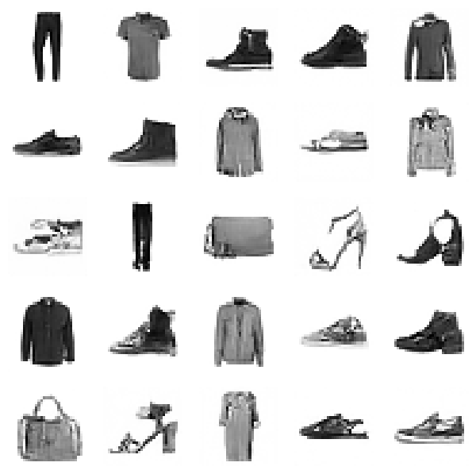

```python
# Display some generated images
show_images(s[:25], imsize=1.5)
```

# Understanding `.prev_sample` in `sched.step()`

## The Code in Question

```
%%time
# Start from pure noise
x_t = torch.randn(sz).cuda()
preds = []  # Store intermediate predictions

# Loop through all timesteps (sched.timesteps goes from 999 to 0)
for t in progress_bar(sched.timesteps):
    # Predict noise at current timestep
    with torch.no_grad():
        noise = model(x_t, t).sample

    # Take one denoising step
    x_t = sched.step(noise, t, x_t).prev_sample

    # Save the result
    preds.append(x_t.float().cpu())
```

**Why do we use `.prev_sample`?**

## The Short Answer

`sched.step()` returns a **named tuple/dataclass** containing multiple outputs, not just a single tensor. `.prev_sample` extracts the specific output we need: the **denoised image at the previous timestep** (x_{t-1}).

## What `sched.step()` Returns

The HuggingFace diffusers library's `scheduler.step()` method returns a `SchedulerOutput` object (a dataclass) that contains multiple fields:

```
res = sched.step(noise, t, x_t)

# res is a SchedulerOutput object containing:
# - res.prev_sample          → x_{t-1} (the image at the previous timestep - WHAT WE NEED!)
# - res.pred_original_sample → x_0 prediction (optional, the predicted clean image)
# - (possibly other fields depending on scheduler)
```

## Why Return Multiple Things?

```
┌─────────────────────────────────────────────────────────────────┐
│                    sched.step() OUTPUT                           │
├─────────────────────────────────────────────────────────────────┤
│                                                                 │
│  Input:                                                         │
│    - noise: model's prediction of the noise in x_t              │
│    - t: current timestep (e.g., 999)                           │
│    - x_t: current noisy image                                  │
│                                                                 │
│  Output (SchedulerOutput):                                      │
│  ┌─────────────────────────────────────────────────────────┐   │
│  │                                                         │   │
│  │  .prev_sample         →  x_{t-1}                       │   │
│  │                          The slightly denoised image    │   │
│  │                          THIS IS WHAT WE NEED!          │   │
│  │                                                         │   │
│  │  .pred_original_sample →  x_0 (predicted clean image)  │   │
│  │                          Optional: what the scheduler   │   │
│  │                          thinks the final image is      │   │
│  │                                                         │   │
│  └─────────────────────────────────────────────────────────┘   │
│                                                                 │
└─────────────────────────────────────────────────────────────────┘
```

The scheduler returns multiple outputs because:

1. **`prev_sample`**: The main output - the image at timestep t-1 (used for the next iteration)
2. **`pred_original_sample`**: Sometimes useful for visualization or other purposes (the predicted final clean image)

## The Denoising Process

```
┌─────────────────────────────────────────────────────────────────┐
│                    DENOISING ITERATION                           │
├─────────────────────────────────────────────────────────────────┤
│                                                                 │
│  Timestep t=999 (very noisy)                                   │
│       │                                                         │
│       ▼                                                         │
│  ┌─────────────┐                                                │
│  │    x_t      │  Current noisy image                          │
│  └──────┬──────┘                                                │
│         │                                                       │
│         ▼                                                       │
│  ┌─────────────┐                                                │
│  │   model()   │  Predict the noise in x_t                     │
│  └──────┬──────┘                                                │
│         │                                                       │
│         ▼                                                       │
│  ┌─────────────┐                                                │
│  │   noise     │  Model's noise prediction                     │
│  └──────┬──────┘                                                │
│         │                                                       │
│         ▼                                                       │
│  ┌──────────────────────────────────────┐                      │
│  │  sched.step(noise, t, x_t)          │                      │
│  │                                      │                      │
│  │  Returns SchedulerOutput:            │                      │
│  │    .prev_sample = x_{t-1}  ◄─────────┼── We extract this!  │
│  │    .pred_original_sample = x_0       │                      │
│  └──────────────────────────────────────┘                      │
│         │                                                       │
│         ▼                                                       │
│  ┌─────────────┐                                                │
│  │  x_{t-1}    │  Slightly less noisy image                    │
│  └─────────────┘                                                │
│         │                                                       │
│         ▼                                                       │
│    (repeat for t=998, 997, ... 0)                              │
│                                                                 │
└─────────────────────────────────────────────────────────────────┘
```

## Code Breakdown

```
# Step 1: Start with noisy image x_t
x_t = torch.randn(sz).cuda()

for t in progress_bar(sched.timesteps):  # t goes from 999 → 0

    # Step 2: Model predicts the noise in x_t
    with torch.no_grad():
        noise = model(x_t, t).sample  # .sample extracts tensor from model output

    # Step 3: Scheduler computes x_{t-1} from x_t and the noise prediction
    result = sched.step(noise, t, x_t)  # Returns SchedulerOutput object

    # Step 4: Extract the previous sample (x_{t-1})
    x_t = result.prev_sample  # This becomes x_t for the next iteration

    # Equivalent one-liner:
    # x_t = sched.step(noise, t, x_t).prev_sample
```

## Why "prev_sample"?

The name `prev_sample` refers to the **previous timestep's sample**:

```
┌─────────────────────────────────────────────────────────────────┐
│                    TIMESTEP NAMING                               │
├─────────────────────────────────────────────────────────────────┤
│                                                                 │
│  In diffusion models, timesteps count DOWN:                     │
│                                                                 │
│    t = 999 → 998 → 997 → ... → 2 → 1 → 0                       │
│    (noisy)                           (clean)                    │
│                                                                 │
│  At timestep t, we compute x_{t-1}:                            │
│                                                                 │
│    Current:   x_t      (at timestep t)                         │
│    Previous:  x_{t-1}  (at timestep t-1, one step closer to 0) │
│                                                                 │
│  "Previous" means previous in the timestep sequence,            │
│  which is actually FORWARD in the denoising process!            │
│                                                                 │
│    t=999 ──► t=998 ──► t=997 ──► ... ──► t=0                   │
│    x_999     x_998     x_997             x_0                    │
│    (noise)   ◄─────────────────────────► (clean image)         │
│              "prev_sample" at each step                         │
│                                                                 │
└─────────────────────────────────────────────────────────────────┘
```

## Why Not Just Return a Tensor?

The HuggingFace design choice to return a dataclass instead of just a tensor provides:

1. **Flexibility**: Different schedulers can return different additional information
2. **Debugging**: You can inspect `pred_original_sample` to see what the model thinks the final image looks like at any step
3. **Extensibility**: New fields can be added without breaking existing code
4. **Clarity**: Named fields are clearer than tuple indexing like `result[0]`

## Comparison: Model Output vs Scheduler Output

Both the model and scheduler return objects (not raw tensors):

```
# Model output - need .sample to get the tensor
noise = model(x_t, t).sample

# Scheduler output - need .prev_sample to get the tensor
x_t = sched.step(noise, t, x_t).prev_sample
```

| Component | Returns | Extract With | What You Get |
| --- | --- | --- | --- |
| `model(x_t, t)` | Model output object | `.sample` | Predicted noise |
| `sched.step(...)` | SchedulerOutput object | `.prev_sample` | Denoised image x_{t-1} |

## What If We Didn't Use `.prev_sample`?

```
# WITHOUT .prev_sample - WRONG!
x_t = sched.step(noise, t, x_t)
# x_t is now a SchedulerOutput object, not a tensor!
# The next iteration would fail because model() expects a tensor

# WITH .prev_sample - CORRECT!
x_t = sched.step(noise, t, x_t).prev_sample
# x_t is now a tensor (the denoised image)
# Ready for the next iteration
```

## Accessing Other Fields (Optional)

If you want to see what the scheduler predicts as the final clean image:

```
result = sched.step(noise, t, x_t)

# The denoised image at t-1 (what we need for iteration)
x_t_minus_1 = result.prev_sample

# The predicted final clean image (x_0) - useful for visualization
predicted_clean = result.pred_original_sample  # May be None for some schedulers
```

## Summary

| Question | Answer |
| --- | --- |
| What does `sched.step()` return? | A `SchedulerOutput` dataclass with multiple fields |
| What is `.prev_sample`? | The denoised image at timestep t-1 (x_{t-1}) |
| Why "prev"? | Previous timestep (t-1 comes before t in the countdown) |
| Why not return just a tensor? | Flexibility - scheduler can return additional info like predicted x_0 |
| What other fields exist? | `.pred_original_sample` (predicted clean image), possibly others |
| Why do we need `.prev_sample`? | To extract the specific tensor we need for the next iteration |
| What happens without it? | We'd have a SchedulerOutput object instead of a tensor - code would break |

```python
# ============================================================================
# INTERACTIVE -- run this cell. It loads ./interactive_viz/8_prev_sample_explained.html
# at full width, sized to fit the visualization (setup cell near the top required).
# .prev_sample: what actually travels around the sampling loop.
# ============================================================================
show_viz("interactive_viz/8_prev_sample_explained.html", height="700px")
```

[interactive chart not shown]